# Arthropods only - 181 CS

2023-10-11

## Script to work on analyses for causes paper

##Taxonomic work is needed? # Morpho differentiation types: More CS sl than CS ss overall? # Need to find expectations and test against 50:50 mark

```
##
##  Pearson's Chi-squared test with Yates' continuity correction
##
## data:  cbind(expected, observed)
## X-squared = 1.9073, df = 1, p-value = 0.1673
```

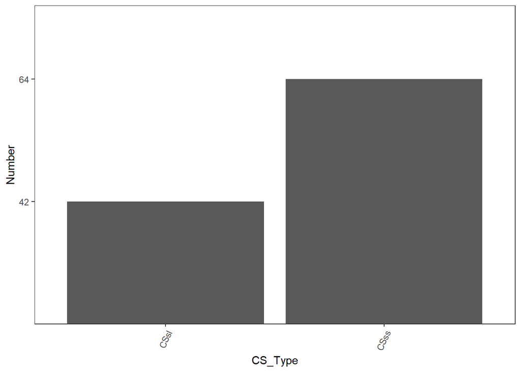

No difference between categories - reject hypothesis. This is a different pattern than everything else so far!

# Available technology – More diagnostic differences in species described earlier?

```
##
##        FALSE TRUE
##   1770     0    1
##   1780     0    1
##   1790     0    2
##   1800     2    1
##   1810     5    1
##   1820     1    3
##   1830     1    2
##   1840     1    3
##   1850     4    0
##   1860     2    3
##   1870     2    1
##   1880     3    3
##   1890     1    1
##   1900     0    6
##   1920     1    1
##   1930     0    4
##   1950     0    1
##   1960     0    1
##   1970     1    3
##   1980     0    3
##   1990     2    3
##   2000     6    1
##   2010     6    3
```

```
##
##  Pearson's Chi-squared test
##
## data:  decademorpho$decade and decademorpho$CSss
## X-squared = 33.934, df = 22, p-value = 0.04989
```

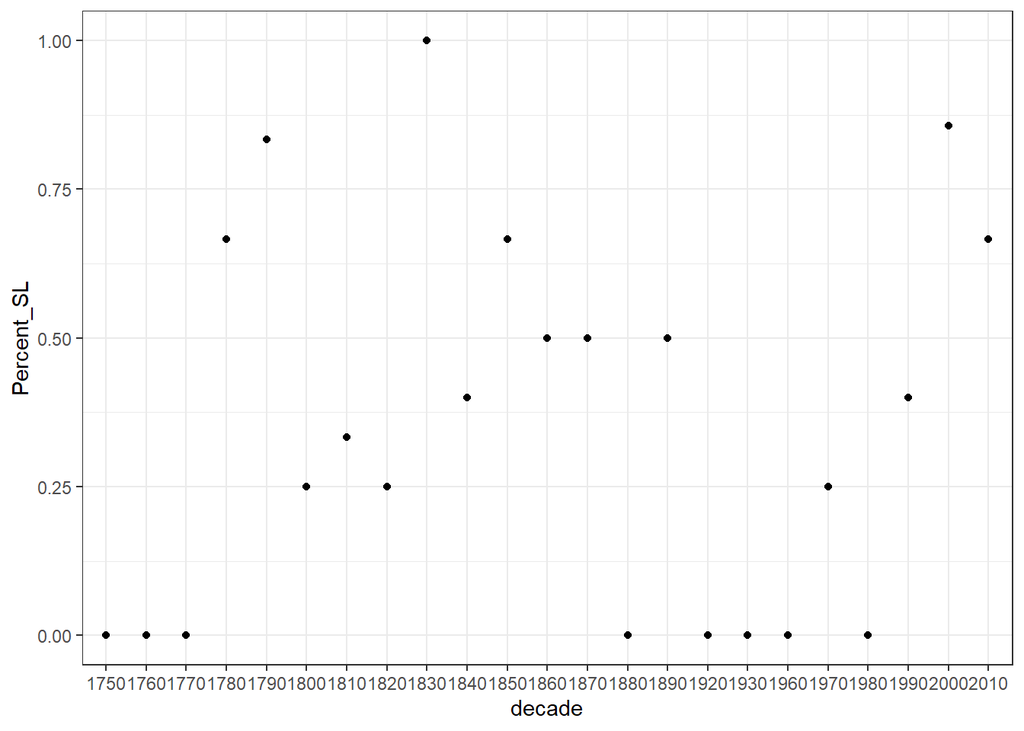

There is no trend in the percent of CSsl (diagnostic differences) through time; hypothesis not supported. However, there are significant differences between decades. Regression?

# Prevailing theories of nature and species origins - More CS in fragmented habitats in species described before Darwin?

```
##
##             10 100 1000 25  5
##   1756-1859 12   2   13 10 10
##   1860-1980 28   5   11  9 11
##   1981-2020  9   5    1  8  5
```

```
##
##  Pearson's Chi-squared test
##
## data:  breaks_HKK$decade_bin and breaks_HKK$HKK
## X-squared = 14.695, df = 8, p-value = 0.06535
```

```
##                   10        100       1000        25         5
## pre_Darwin 0.2553191 0.04255319 0.27659574 0.2127660 0.2127660
## pre_Kimura 0.4375000 0.07812500 0.17187500 0.1406250 0.1718750
## modern     0.3214286 0.17857143 0.03571429 0.2857143 0.1785714
```

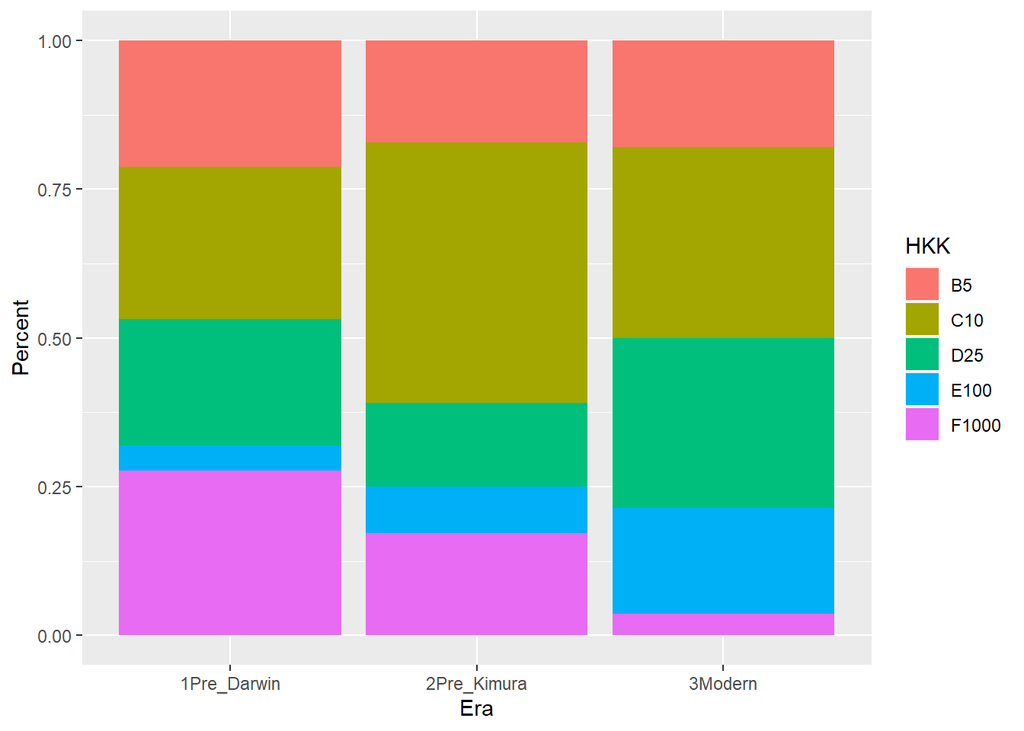

# Accessibility of habitat when species described - Percentage of CS in inaccessible habitats higher in earlier spp?

```
##
##        Difficult Easy Normal
##   1750         0    0      1
##   1770         0    0      3
##   1780         0    1      0
##   1790         0    2      0
##   1800         0    1      3
##   1810         0    1      6
##   1820         2    0      4
##   1830         0    4      2
##   1840         1    4      8
##   1850         0    3      7
##   1860         0    1      8
##   1870         0    4      4
##   1880         0    0     11
##   1890         0    3      2
##   1900         1    1      5
##   1910         3    2      1
##   1920         0    1      2
##   1930         0    2      5
##   1950         0    1      2
##   1960         0    0      1
##   1970         0    2      2
##   1980         4    0      0
##   1990         0    0      5
##   2000         3    2      5
##   2010         0    3      8
```

```
##
##  Pearson's Chi-squared test
##
## data:  decadeAccess$decade and decadeAccess$Access
## X-squared = 102.31, df = 48, p-value = 8.399e-06
```

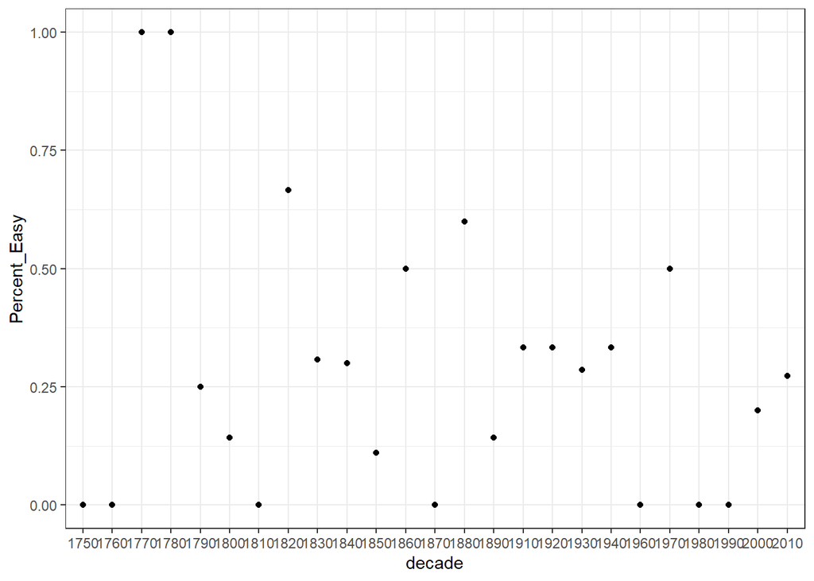

Hypothesis maybe supported? General downward trend, though the first two decades are low.

## In sum, when we only look at species with CS (i.e. our database), the effect of taxonomic work goes away. This is interesting since that was the strongest effect in paper 1. THIS IS STILL TRUE with the arthropods, though note some support for habitat access.

## Effect of recent divergence - dispersal

# Larval type – Planktotrophic/pelagic larvae leads to less CS/NS)?

Note1: for this I’m working with a separate surveylarv input file where I have corrected larval types to pt, lt, dd, and removed all others, including cases where there are multiple types checked. (Most of those cases are where the two CS have different larvae.) This left 107 CS with larval info.

Note2: the data fail the homoscedasticity test (Bartlett’s) so I’ve used a nonparametric Kruskal-Wallis test to see if CS/NS is different among groups.

```
##       DD       PT
## 3.622642 2.777778
```

```
##       DD       PT
## 2.363394 1.253925
```

```
##
##  Kruskal-Wallis rank sum test
##
## data:  as.numeric(larv_NbCS$Nb_CS) and larv_NbCS$Larv_type
## Kruskal-Wallis chi-squared = 3.4091, df = 1, p-value = 0.06484
```

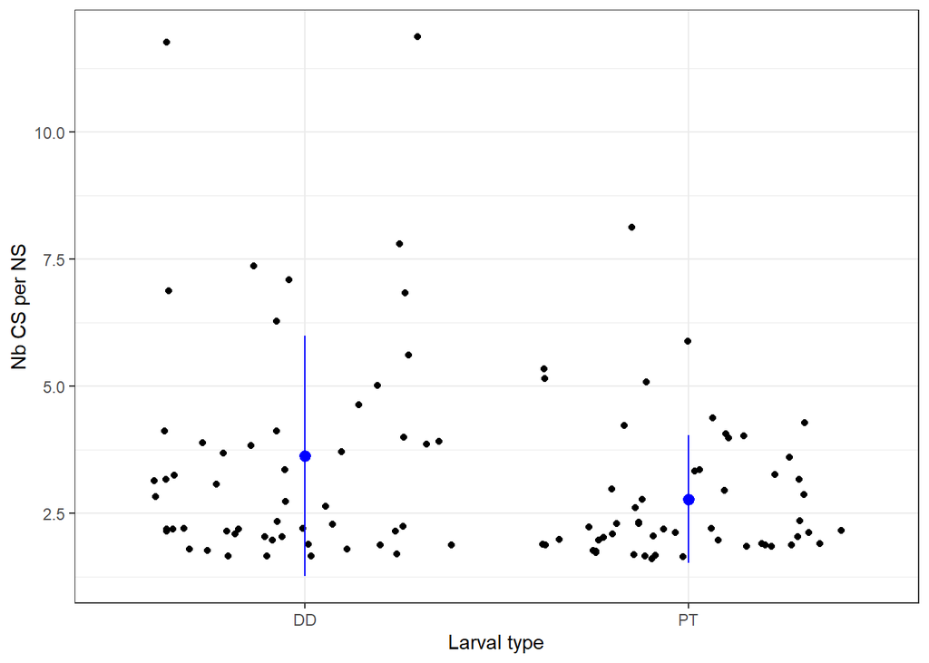

Hypothesis marginally supported. DD with higher CS per NS.

# High HKK leads to more CS ss – testing this based on Nb_CS per HKK.

Note: data again failed homoscedasticity, using Kruskal Wallis test

```
##        5       10       25      100     1000
## 3.437500 3.750000 2.387097 3.615385 3.400000
```

```
##        5       10       25      100     1000
## 2.031010 3.046608 0.843699 1.709701 2.698659
```

```
##
##  Kruskal-Wallis rank sum test
##
## data:  HKK_NbCS$Nb_CS and HKK_NbCS$HKKv3
## Kruskal-Wallis chi-squared = 11.177, df = 4, p-value = 0.02465
```

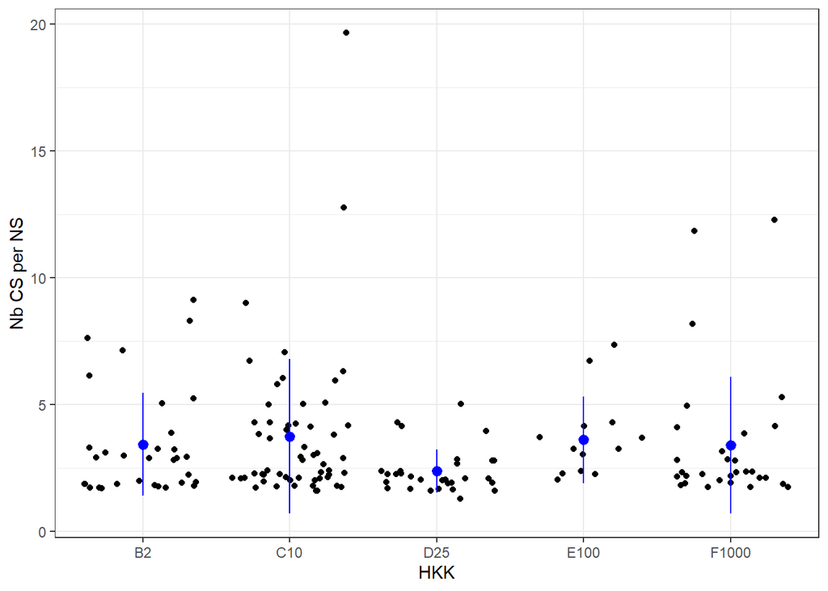

## In sum, some support for the role of recent divergence as measured by a proxy of dispersal when considering only the arthropods.

# More stable environments = more CSss or statistical differences

Note: stable = pelagic, deepsea, cave, coralreef; not stable = coastal, intertidal, estuarine, seagrass

```
##
##         FALSE TRUE
##   FALSE    33    9
##   TRUE     34   30
```

```
##
##  Pearson's Chi-squared test with Yates' continuity correction
##
## data:  stable_hab$CSss and stable_hab$Stable
## X-squared = 6.0089, df = 1, p-value = 0.01423
```

```
##                FALSE      TRUE
## CSss_total 0.5074627 0.7692308
## CSsl_total 0.4925373 0.2307692
```

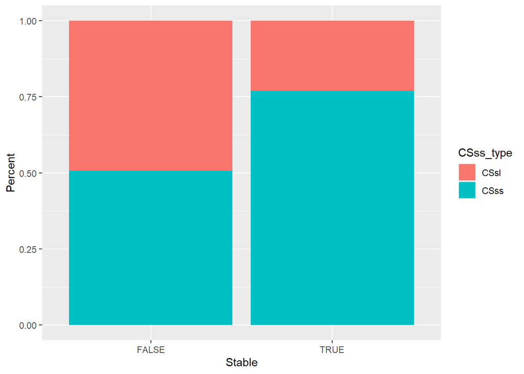

Result: More CSss found in stable environments. Hypothesis supported.

# Note also that stabilizing selection predicts more CSss than CSsl, which is not what we find (see above).

## In sum, we generally have support for this idea.

## High Ne (neutral hypotheses)

# Reproductive investment - Low reproductive investment leads to more statistical divergence? (Repro. investment proxy for Ne)

Note1: Again this uses the surveylarv dataset with hand cleaning. Note2: Planktotrophic = LOW; Lecithotrophic, Brooding, DD = HIGH; If a spp could be both low and high, have marked it NA (is usually bc the CS have different larval types). Anything else got marked NA to be conservative. Note3: Only 61 cases are considered here, meaning that is where we have morphological data AND larval type data AND Arthropod

```
##
##                      HIGH LOW
##   Diagnostic            8  13
##   No differentiation    5   7
##   Statistic            13  15
```

```
##
##  Pearson's Chi-squared test
##
## data:  surveylarv$Morpho_diff and surveylarv$Repro_invest
## X-squared = 0.34634, df = 2, p-value = 0.841
```

Result: not significant.

# High HKK leads to more CS ss (HKK as proxy for Ne)

```
##
##                       5 10 25 100 1000
##   Diagnostic          7 12 17   3    0
##   No differentiation  6  6  1   1    1
##   Statistic           9 15  8   4    9
```

```
##                    5        10         25   100 1000
## stat_total 0.4090909 0.4545455 0.30769231 0.500  0.9
## diag_total 0.3181818 0.3636364 0.65384615 0.375  0.0
## nod_total  0.2727273 0.1818182 0.03846154 0.125  0.1
```

```
##
##    5   10   25  100 1000
##   22   33   26    8   10
```

```
##
##  Pearson's Chi-squared test
##
## data:  surveymorpho$Morpho_diff and surveymorpho$HKKv3
## X-squared = 19.277, df = 8, p-value = 0.01345
```

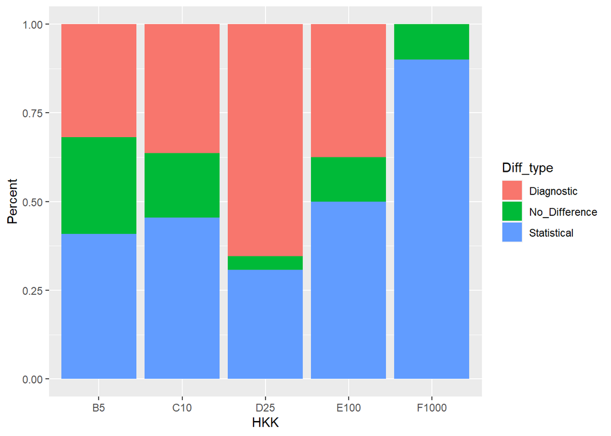

```
##
##        FALSE TRUE
##   5        7   15
##   10      12   21
##   25      17    9
##   100      3    5
##   1000     0   10
```

```
##
##  Pearson's Chi-squared test
##
## data:  surveymorpho$HKKv3 and surveymorpho$CSss
## X-squared = 14.524, df = 4, p-value = 0.005797
```

```
##                    5        10        25   100 1000
## CSss_total 0.6818182 0.6363636 0.3461538 0.625    1
## CSsl_total 0.3181818 0.3636364 0.6538462 0.375    0
```

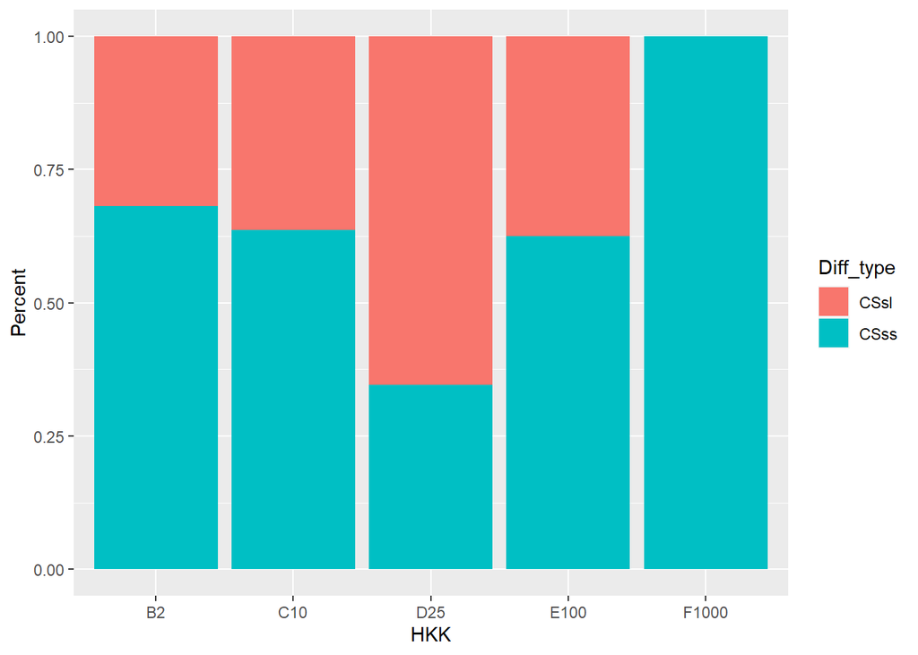

Results: Very significant, but the clearest pattern is a high number of diagnostic diffs in organisms at HKK=25, with a u-shaped curve instead of a linear trend. Investigate further.

## In sum, we MAY see support for the neutral hypothesis if we use HKK as a proxy for Ne but NOT if we use reproductive investment.

## Hypothesis: effect of recent divergence – More sympatric than allopatric CS/NS for a given Nsg?

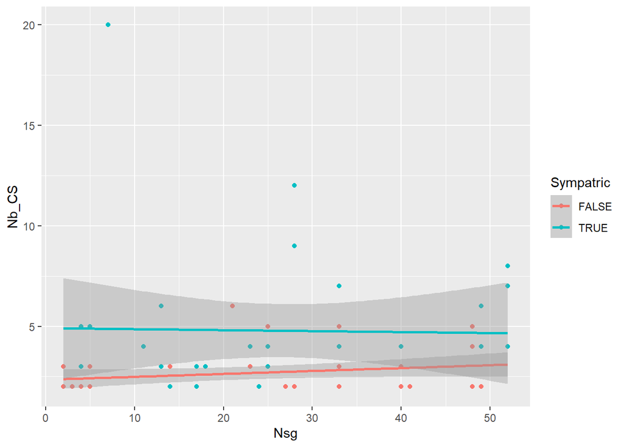

```
## ANOVA Table (type II tests)
##
##      Effect DFn DFd     F     p p<.05   ges
## 1     Nb_CS   1  71 0.185 0.668       0.003
## 2 Sympatric   1  71 0.836 0.364       0.012
```

These results aren’t statistically significant (ANCOVA) but the graph is in line with the hypothesis. Marginal support.

## Selection against hybrids – More diagnostic differences in sympatry than allopatry?

```
##
##         FALSE TRUE
##   FALSE    19    5
##   TRUE     15   19
```

```
##
##  Pearson's Chi-squared test with Yates' continuity correction
##
## data:  surveymorpho$CSss and surveymorpho$Sympatric
## X-squared = 5.7533, df = 1, p-value = 0.01646
```

```
##                FALSE      TRUE
## CSss_total 0.4411765 0.7916667
## CSsl_total 0.5588235 0.2083333
```

[figure not shown]

## Importance of biological traits

# More diagnostic traits with hard skeleton?

```
##
##                       N  Y
##   Diagnostic          0 38
##   No differentiation  0 15
##   Statistic           0 31
```

```
##              N         Y
## stat_total NaN 0.3690476
## diag_total NaN 0.4523810
## nod_total  NaN 0.1785714
```

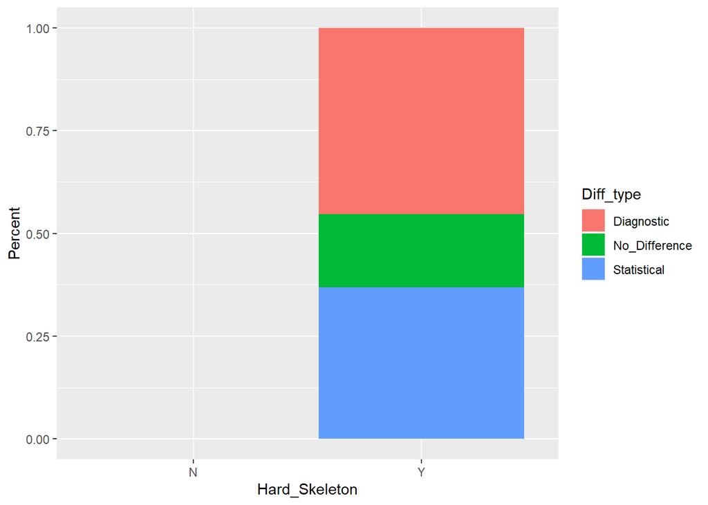

Everyone has a hard skeleton, so no test.

# More diagnostic traits with image vision?

```
##
##                       N  Y
##   Diagnostic          4 34
##   No differentiation  1 14
##   Statistic           4 27
```

```
##
##  Pearson's Chi-squared test
##
## data:  surveymorpho$Morpho_diff and surveymorpho$image
## X-squared = 0.41356, df = 2, p-value = 0.8132
```

```
##                    N         Y
## stat_total 0.4444444 0.3600000
## diag_total 0.4444444 0.4533333
## nod_total  0.1111111 0.1866667
```

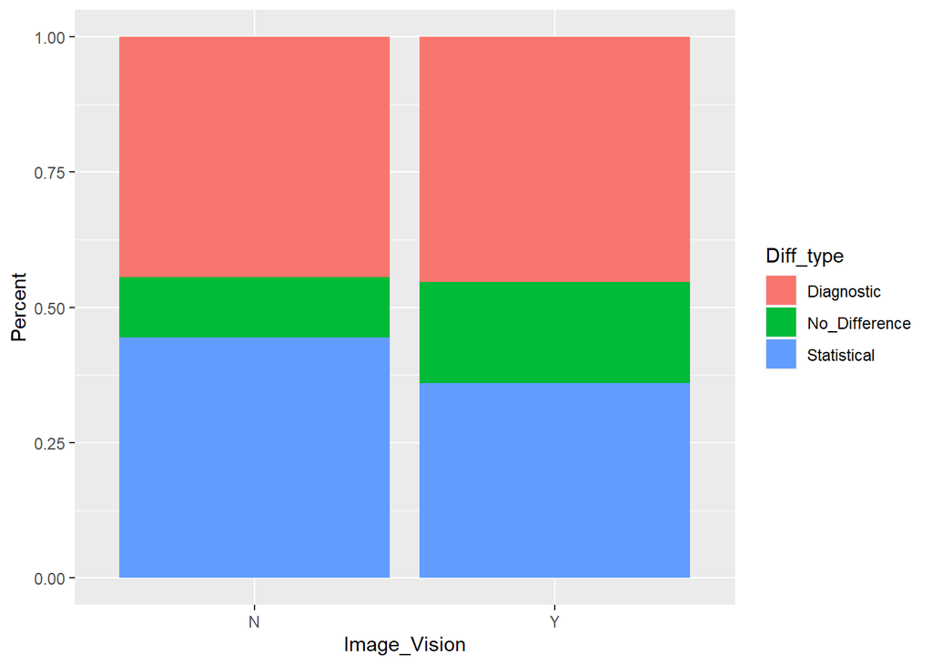

Result: hypothesis not supported.

# More diagnostic traits with internal fertilization?

```
##
##                       B  E  I
##   Diagnostic          0  4 34
##   No differentiation  0  1 14
##   Statistic           0  1 30
```

```
##
##  Pearson's Chi-squared test
##
## data:  surveymorpho$Morpho_diff and surveymorpho$ferti
## X-squared = 1.3781, df = 2, p-value = 0.502
```

```
##              B         E         I
## stat_total NaN 0.1666667 0.3846154
## diag_total NaN 0.6666667 0.4358974
## nod_total  NaN 0.1666667 0.1794872
```

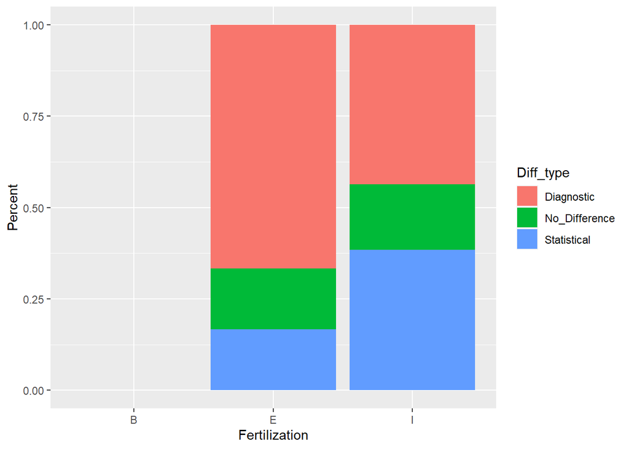

Result: hypothesis not supported. Very small number of external fertilization, though.

# More diagnostic traits with external genitalia?

```
##
##                       B  N  Y
##   Diagnostic          0  4 34
##   No differentiation  0  1 14
##   Statistic           0  1 30
```

```
##
##  Pearson's Chi-squared test
##
## data:  surveymorpho$Morpho_diff and surveymorpho$genitals
## X-squared = 1.3781, df = 2, p-value = 0.502
```

```
##              B         N         Y
## stat_total NaN 0.1666667 0.3846154
## diag_total NaN 0.6666667 0.4358974
## nod_total  NaN 0.1666667 0.1794872
```

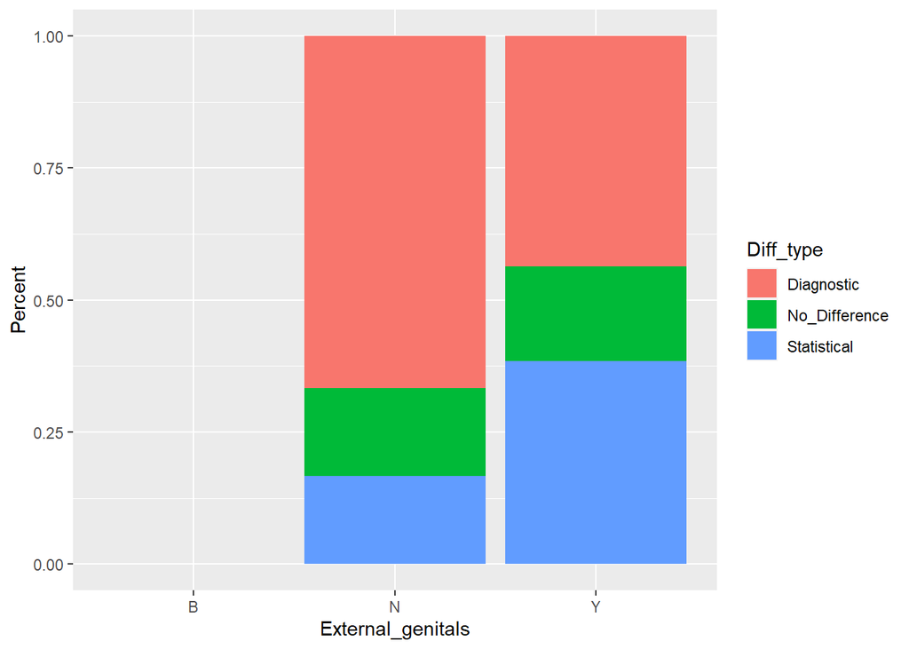

Result: Same as above; no support.